# Canonical Correlation Analysis

ChatGPT 4o

2025-01-21

## 1 起源

典型相关分析（Canonical Correlation Analysis, CCA）是由统计学家哈罗德·霍特林（Harold Hotelling）在1936年提出的一种多变量统计方法。典型相关分析的目的是衡量两个多变量集合之间的相关性。作为一种多元分析方法，CCA被广泛应用于心理学、生态学和经济学等多个领域，用于探索变量之间的复杂关系。

## 2 原理

典型相关分析的基本原理是通过寻找线性组合，使得两个变量集合之间的相关性最大化。假设有两个多变量集合，$X = (X_1, X_2, \dots, X_p)$ 和 $Y = (Y_1, Y_2, \dots, Y_q)$，CCA的目标是找到线性组合：

$$U = a_1X_1 + a_2X_2 + \cdots + a_pX_p$$
$$V = b_1Y_1 + b_2Y_2 + \cdots + b_qY_q$$

使得$U$和$V$之间的相关性最大化。$U$和$V$称为典型变量，$a_i$和$b_i$是典型系数。通过找到多个典型变量对，CCA可以揭示两个变量集合之间的相关结构。

## 3 适用范围

典型相关分析适用于以下情况：

- **多变量关联研究**：当需要分析两个多变量集合之间的相关性时，CCA非常有用。
- **线性关系**：典型相关分析假设变量之间存在线性关系，因此适用于线性相关性较强的数据。
- **样本量足够大**：典型相关分析需要较大的样本量来保证结果的稳定性，尤其是当变量维度较高时。

## 4 应用情境

典型相关分析在多个领域中都有广泛应用，例如：

- **心理学**：用于分析不同心理测试之间的相关性，探索心理因素之间的关系。
- **经济学**：分析经济指标与社会指标之间的关系，例如GDP增长率与社会发展指标之间的关联。
- **生态学**：用于分析环境变量与生物特征之间的相关性，揭示环境因素对生物群体的影响。
- **教育学**：研究学生的学业表现与心理素质之间的关联，帮助理解影响学业的多重因素。

## 5 优缺点

### 优点

- **揭示复杂关联**：CCA能够揭示两个多变量集合之间的复杂相关性，有助于理解变量之间的关联结构。
- **多变量处理**：同时处理两个变量集合中的多个变量，使得分析更加全面。
- **无标签需求**：CCA是一种探索性分析方法，不需要对数据进行标签或分类。

### 缺点

- **对线性关系的依赖**：CCA假设变量之间的关系是线性的，如果这种假设不成立，结果的解释力会降低。
- **对数据要求较高**：需要较大的样本量来保证分析的稳健性，尤其是在变量数量较多的情况下。
- **结果解释困难**：典型变量是原始变量的线性组合，可能难以解释其具体含义。

## 6 在R中的实现及结果解释

在R中，可以使用`CCA`包中的`cc()`函数进行典型相关分析。以下是一个实现典型相关分析的示例：

```r
# 加载必要的包
library(CCA)
library(ggplot2)
```

```r
# 示例数据：创建两个变量集合X和Y
set.seed(123)
X <- matrix(rnorm(100 * 3), ncol = 3)
Y <- matrix(rnorm(100 * 2), ncol = 2)

# 进行典型相关分析
cca_result <- cc(X, Y)
cca_result
```

```
## $cor
## [1] 0.24442712 0.07669156
##
## $names
## $names$Xnames
## NULL
##
## $names$Ynames
## NULL
##
## $names$ind.names
## NULL
##
##
## $xcoef
```

[output cut: 238 more lines]

```r
summary(cca_result)
```

```
##        Length Class  Mode
## cor    2      -none- numeric
## names  3      -none- list
## xcoef  6      -none- numeric
## ycoef  4      -none- numeric
## scores 6      -none- list
```

```r
str(cca_result)
```

```
## List of 5
##  $ cor   : num [1:2] 0.2444 0.0767
##  $ names :List of 3
##   ..$ Xnames   : NULL
##   ..$ Ynames   : NULL
##   ..$ ind.names: NULL
##  $ xcoef : num [1:3, 1:2] -0.943 -0.566 -0.228 0.406 -0.759 ...
##  $ ycoef : num [1:2, 1:2] 0.112 1.006 -0.956 0.098
##  $ scores:List of 6
##   ..$ xscores       : num [1:100, 1:2] 0.48 -0.176 -1.218 0.058 0.563 ...
##   ..$ yscores       : num [1:100, 1:2] -0.256 -1.362 -0.846 -0.249 0.524 ...
##   ..$ corr.X.xscores: num [1:3, 1:2] -0.806 -0.511 -0.123 0.327 -0.733 ...
##   ..$ corr.Y.xscores: num [1:2, 1:2] 0.0237 0.24277 -0.07633 0.00891
##   ..$ corr.X.yscores: num [1:3, 1:2] -0.197 -0.1249 -0.0299 0.0251 -0.0562 ...
##   ..$ corr.Y.yscores: num [1:2, 1:2] 0.097 0.993 -0.995 0.116
```

```r
# 输出典型相关系数
print(cca_result$cor)
```

```
## [1] 0.24442712 0.07669156
```

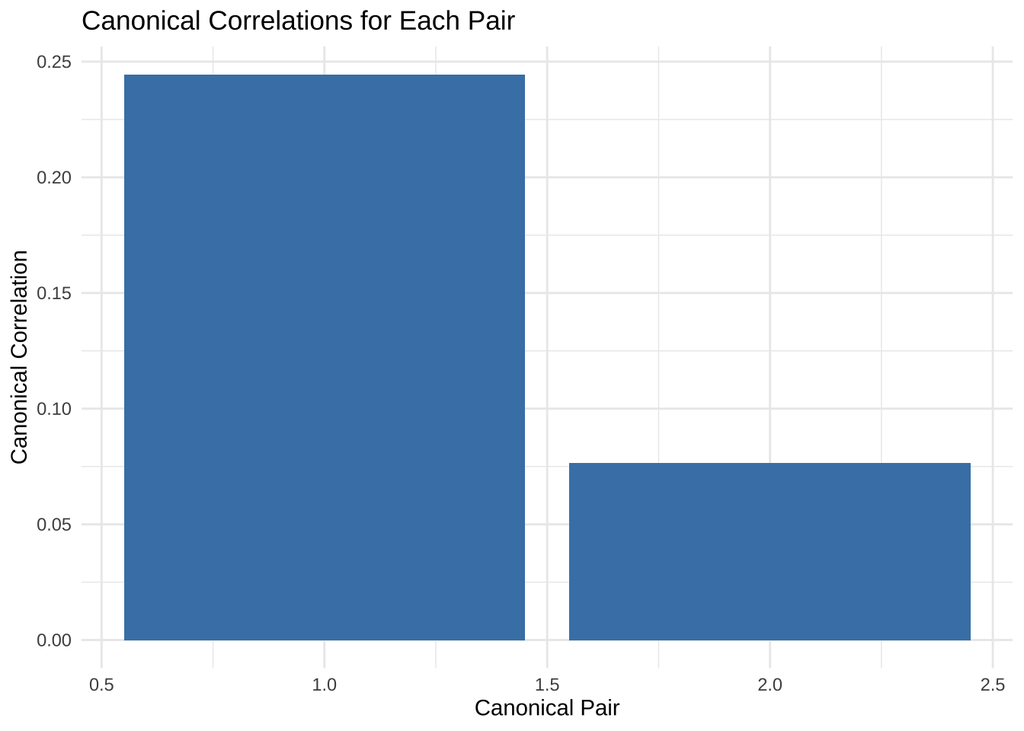

```r
# 可视化典型变量的相关性
canonical_cor <- data.frame(Canonical_Correlation = cca_result$cor, Pair = 1:length(cca_result$cor))

ggplot(canonical_cor, aes(x = Pair, y = Canonical_Correlation)) +
  geom_bar(stat = "identity", fill = "steelblue") +
  labs(title = "Canonical Correlations for Each Pair", x = "Canonical Pair", y = "Canonical Correlation") +
  theme_minimal()
```

### 结果解释

- **典型相关系数**：`cca_result$cor` 包含了每一对典型变量之间的相关系数，反映了两个变量集合之间的相关性大小。通常会选择具有较高相关系数的典型变量对进行进一步解释。
- **可视化结果**：通过条形图展示每一对典型变量之间的相关性，便于直观地比较各对典型变量的相关性强度。较高的典型相关系数表明两个变量集合之间存在较强的线性关系。

## 7 小结

- 典型相关分析是一种用于探索两个多变量集合之间相关性的统计方法。
- 适用于多变量关联研究，能够揭示两个变量集合之间的复杂线性关系。
- 具有揭示复杂关联、多变量处理的优点，但对线性关系的依赖较强，且需要较大的样本量。
- 可以通过R中的`cc()`函数实现典型相关分析，并结合可视化工具直观展示结果。
- 在心理学、经济学、生态学和教育学等领域，典型相关分析是一种重要的工具，用于理解复杂的变量关联。